# EVAR practice and outcomes - elective EVAR

Number, gender, age, year and stent-graft used

Martin Hennessy, Collum O’Hare, Tom Gordon, Sophie Adams

22/12/2019

# 1 Details about elective EVAR performed

## 1.1 Timescale covered and number of elective EVAR

- This document covers elective EVAR performed between 1996-09-19 and 2019-12-19 for abdominal aortic aneurysms
- ie. common iliac artery aneurysms are excluded as well as symptomatic AAAs, ruptures etc.
- This comprises **937** elective EVAR
- Of these, the numbers are split among the Health Boards as detailed below:

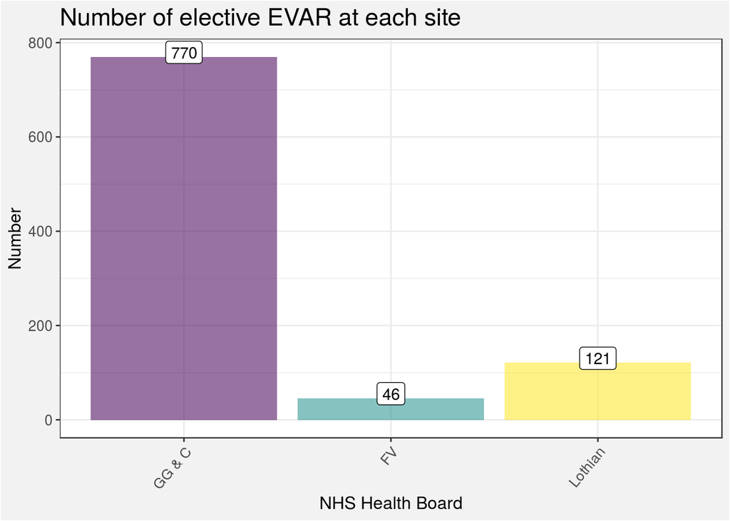

## 1.2 Gender

### 1.2.1 Number of elective EVAR by gender

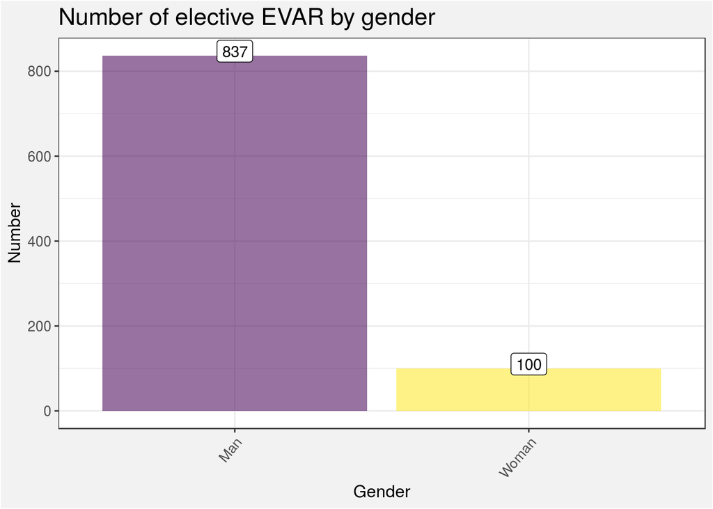

- 10.7% of elective EVAR have been performed in women

### 1.2.2 Number of elective EVAR performed by gender at each site

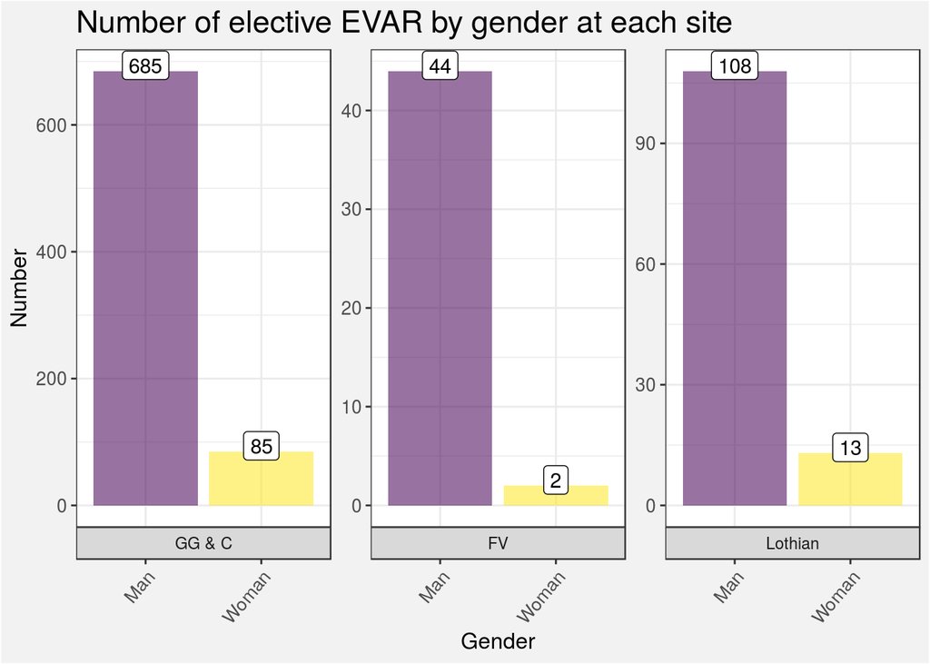

- In GG & C, 11% of elective EVAR have been performed in women
- In FV, 4.3% of elective EVAR have been performed in women
- In Lothian, 10.7% of elective EVAR have been performed in women

## 1.3 Age

### 1.3.1 Number of elective EVAR performed at each patient age

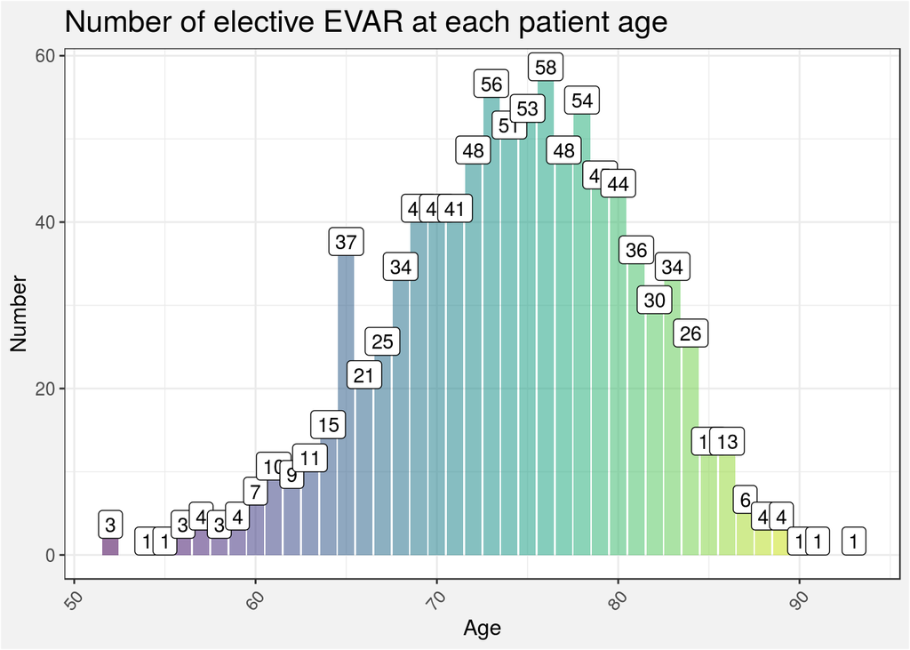

### 1.3.2 Number of elective EVAR performed at each patient age at each site

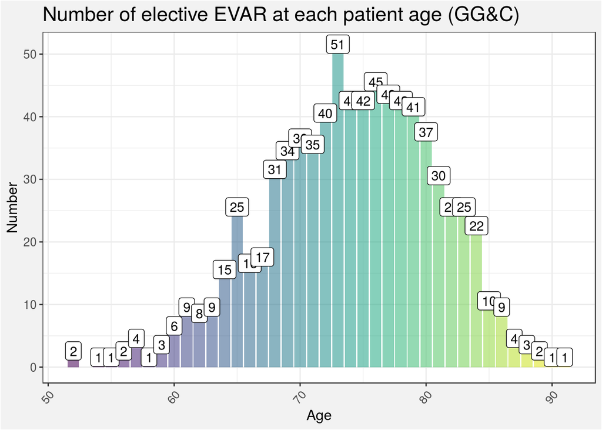

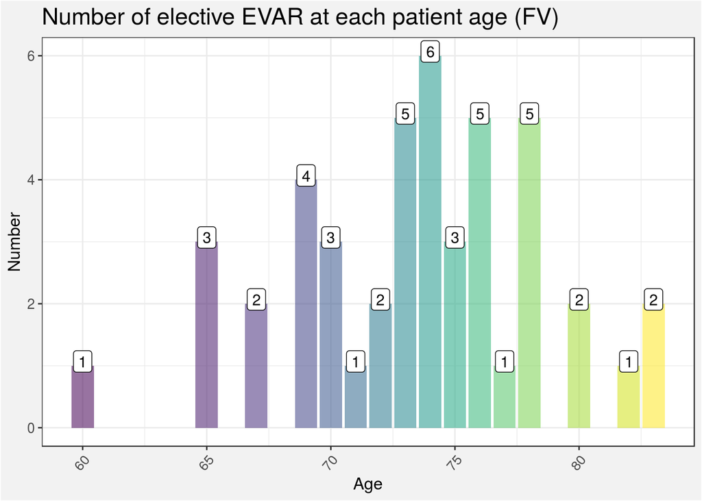

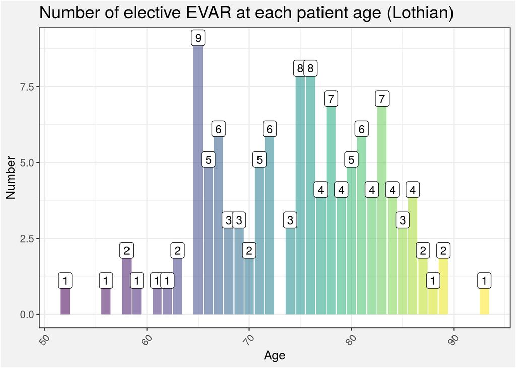

### 1.3.3 Mean and median age of patient when elective EVAR performed for each indication

| Indication | Median | Mean |
| --- | --- | --- |
| Elective AAA | 75 | 74.2 |

### 1.3.4 Mean and median age of patient when elective EVAR performed for each indication at each site

| Indication | HealthBoard | Median | Mean |
| --- | --- | --- | --- |
| Elective AAA | GG & C | 74 | 74.1 |
| Elective AAA | FV | 74 | 73.5 |
| Elective AAA | Lothian | 76 | 74.8 |

### 1.3.5 Boxplot of age at which elective EVAR was performed for each indication

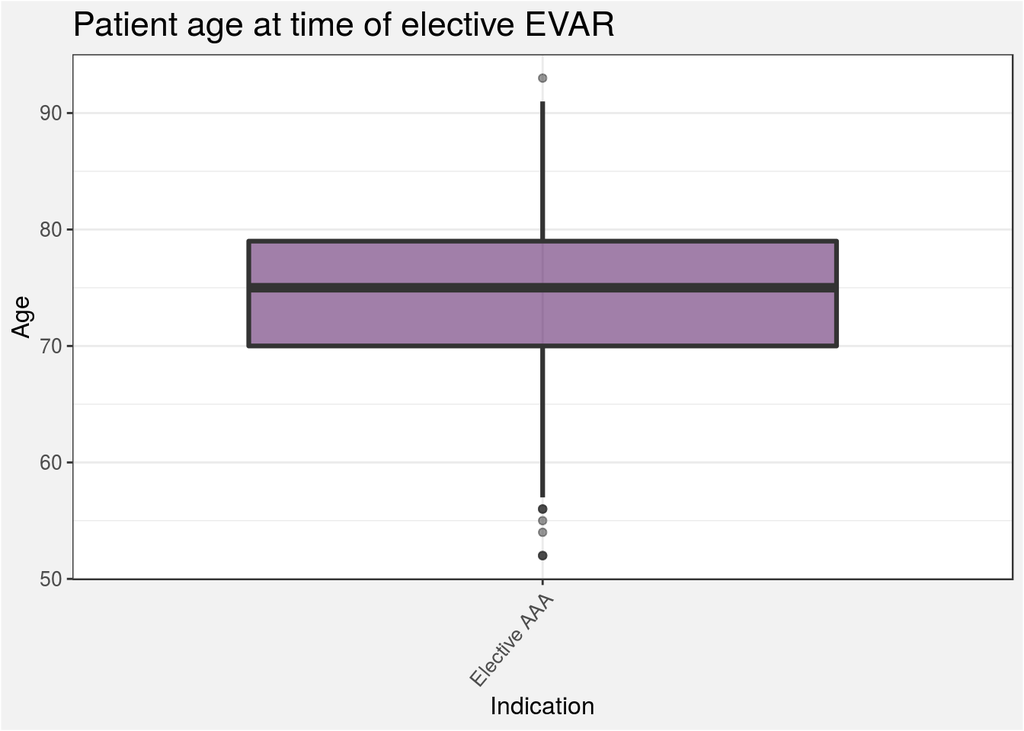

### 1.3.6 Boxplot of age at which elective EVAR was performed for each indication at each site

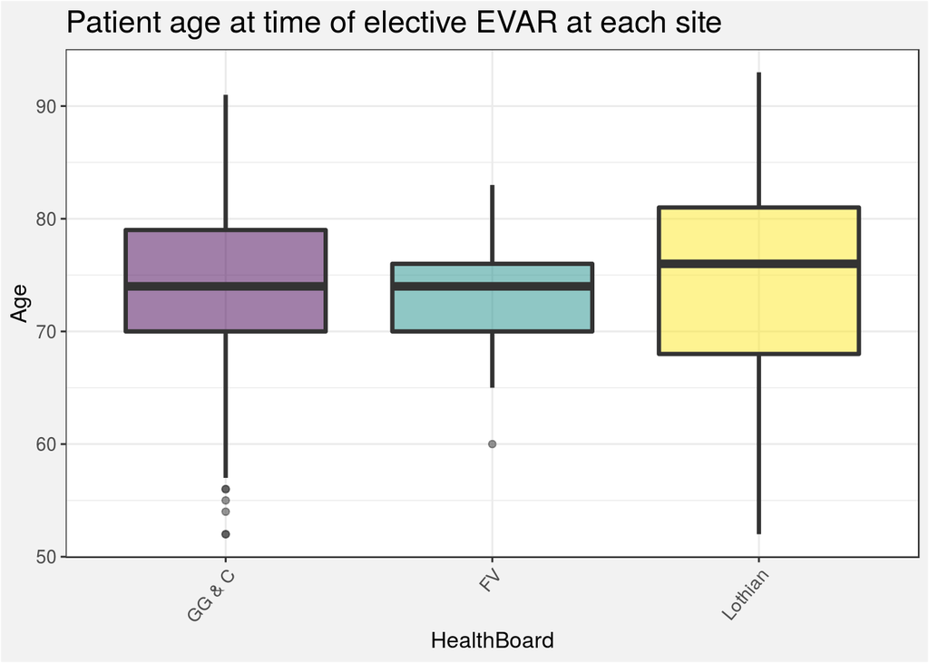

### 1.3.7 Boxplot of age at which elective EVAR was performed each year

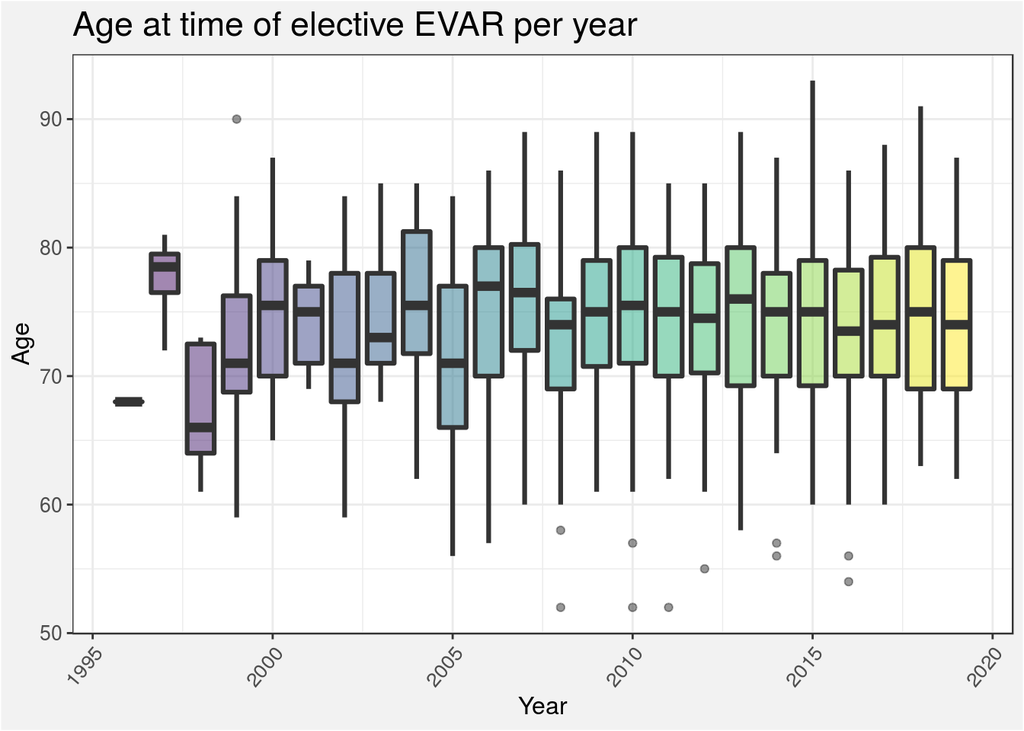

### 1.3.8 Boxplot of age at which elective EVAR was performed each year at each site

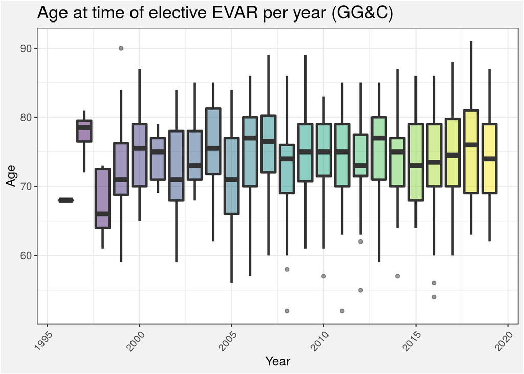

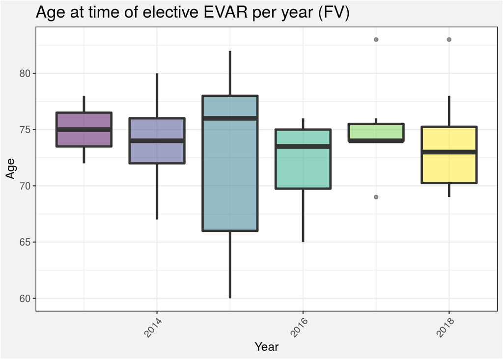

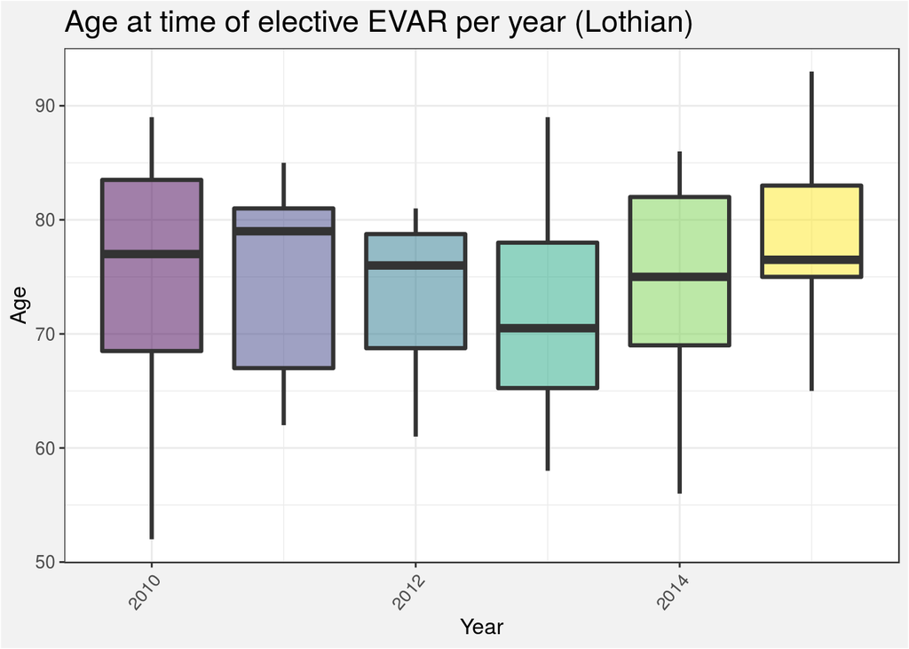

### 1.3.9 Boxplot of age at which elective EVAR was performed by gender

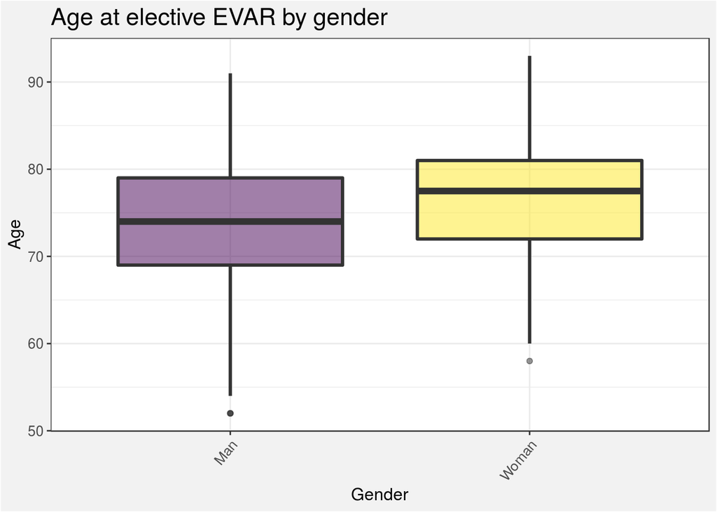

### 1.3.10 Mean and median age of patient when elective EVAR was performed by gender

| Gender | Median | Mean |
| --- | --- | --- |
| Man | 74.0 | 73.9 |
| Woman | 77.5 | 76.2 |

### 1.3.11 Number of elective EVAR by patients’ decade of life

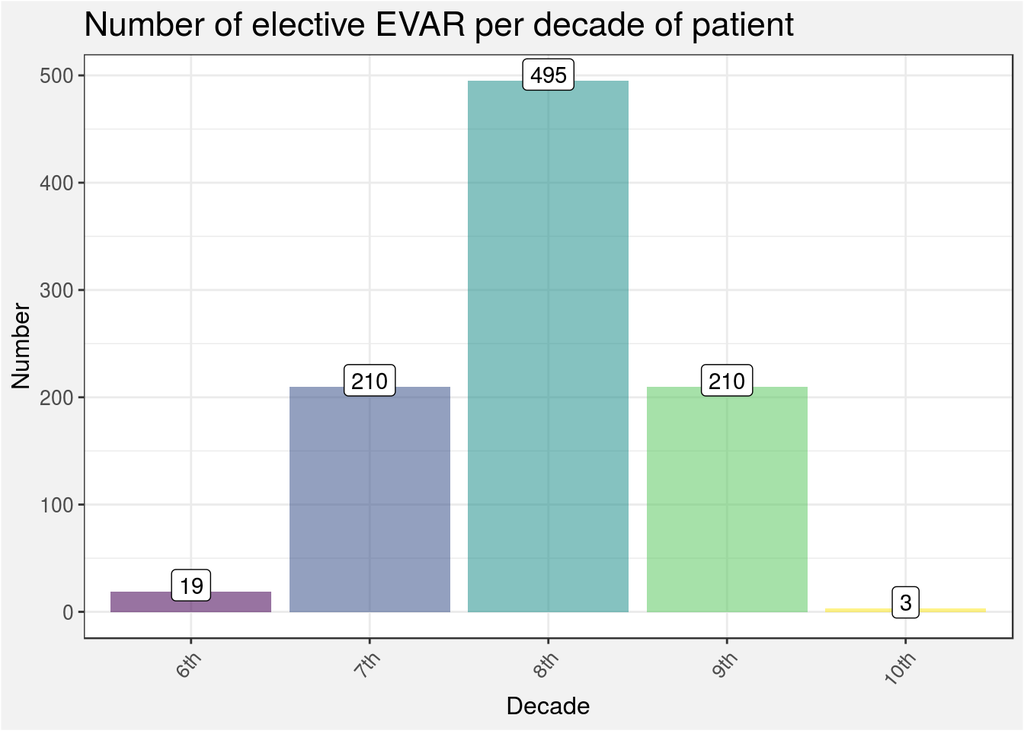

- Due to the small number of patients, those who were in their 6th or 10th decades at time of elective EVAR are ommitted from the following.
- Boxplot of spread of ages in 7th, 8th or 9th decade:

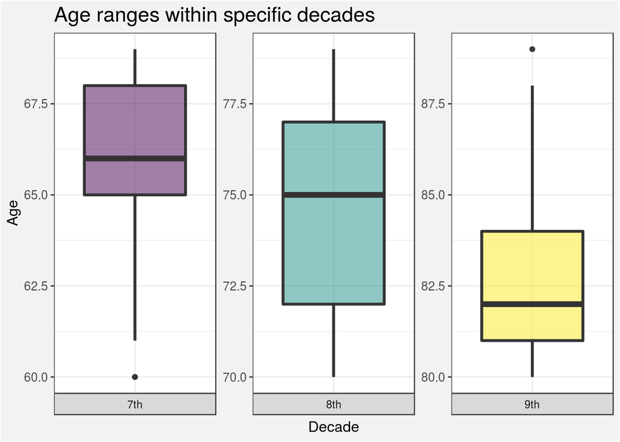

All sites, all years

- Patients in their 7th decade skew slightly towards the upper aspect of that decade
- Patients in their 8th decade, the decade in which most elective EVARs are performed, are evenly spread
- Patients in their 9th decade skew greatly towards the young ages of that decade
- The median and means from the above boxplot are shown in this table:

| Decade | Median | Mean |
| --- | --- | --- |
| 7th | 66 | 65.9 |
| 8th | 75 | 74.6 |
| 9th | 82 | 82.6 |

## 1.4 Year

### 1.4.1 Number of elective EVAR performed each year

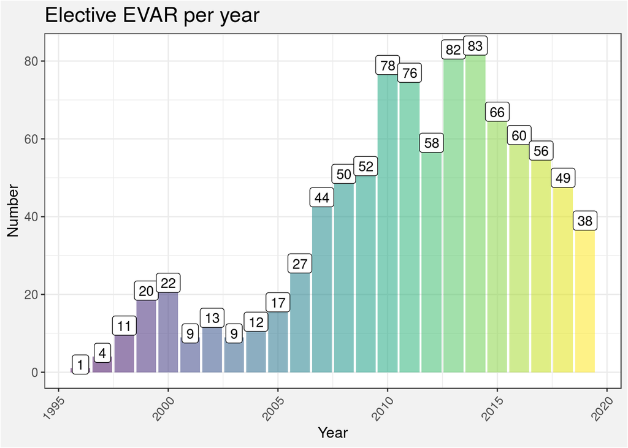

### 1.4.2 Number of elective EVAR performed each year at each site

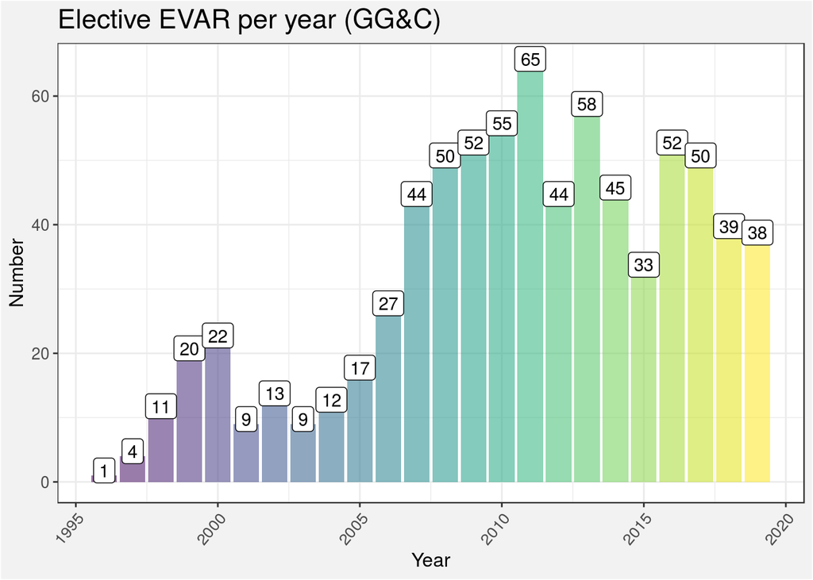

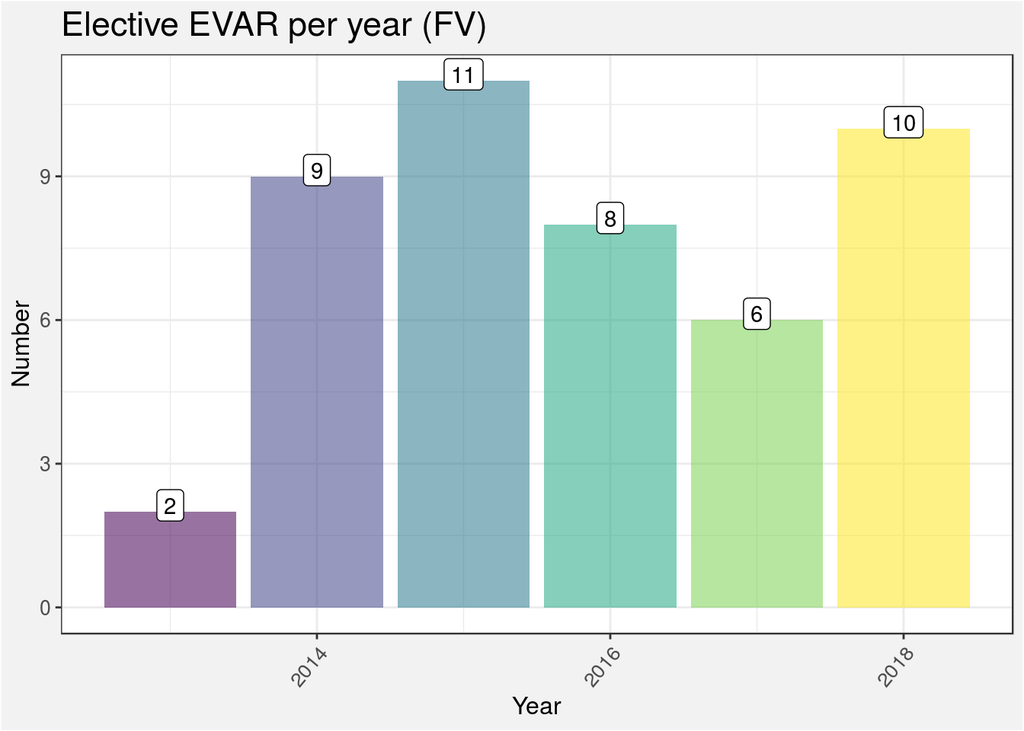

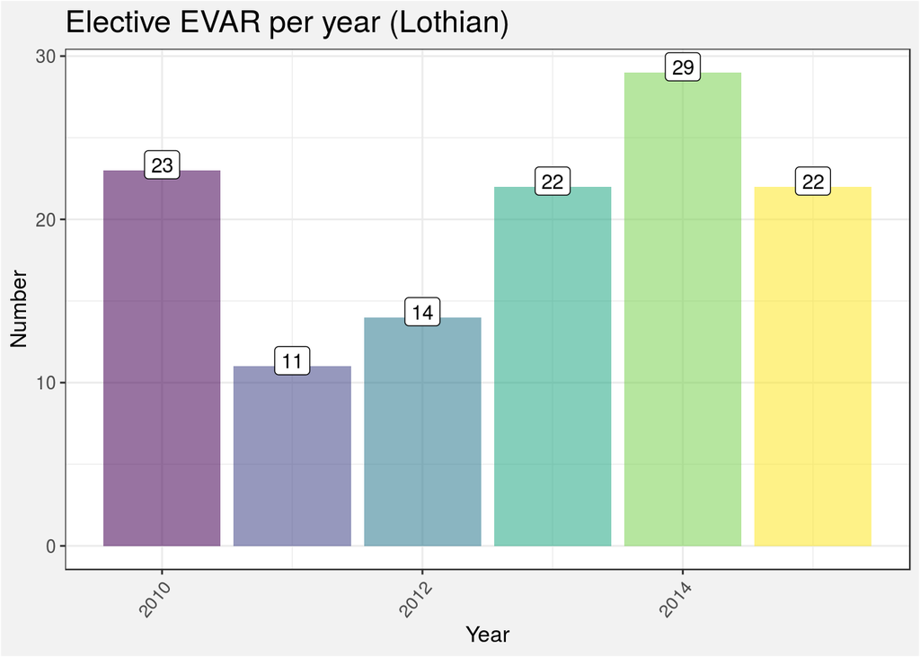

## 1.5 Year Group

- To visualise the data about years a different way, the data are grouped into ‘year groups’ of five years, eg. 2010-2014, 2015-2019 etc

### 1.5.1 Number of elective EVAR performed in each year group

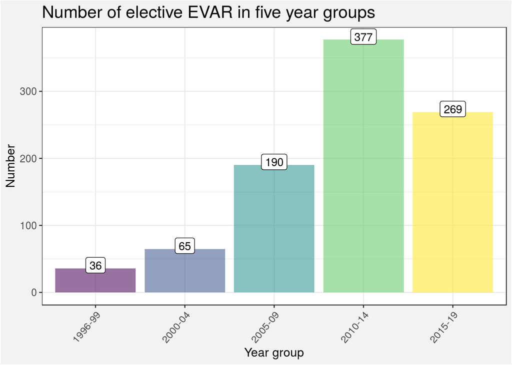

### 1.5.2 Number of elective EVAR performed in each year group

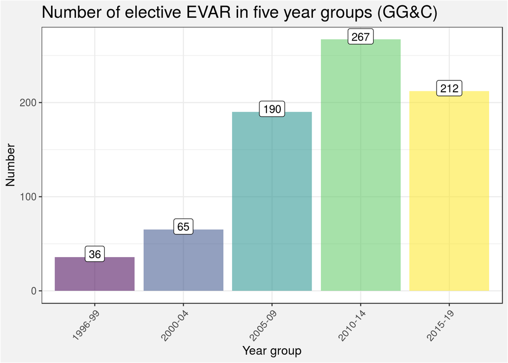

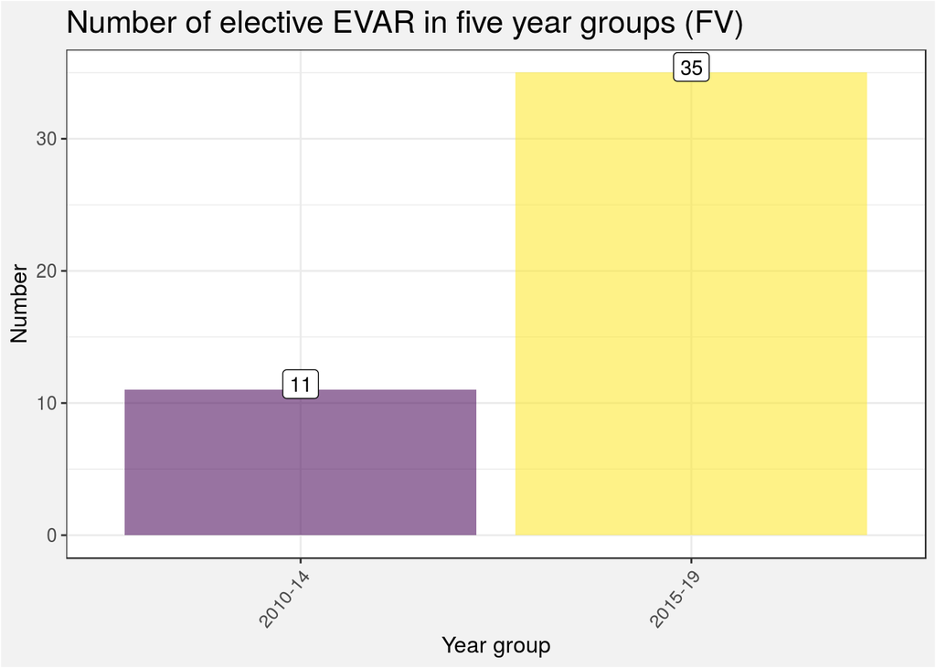

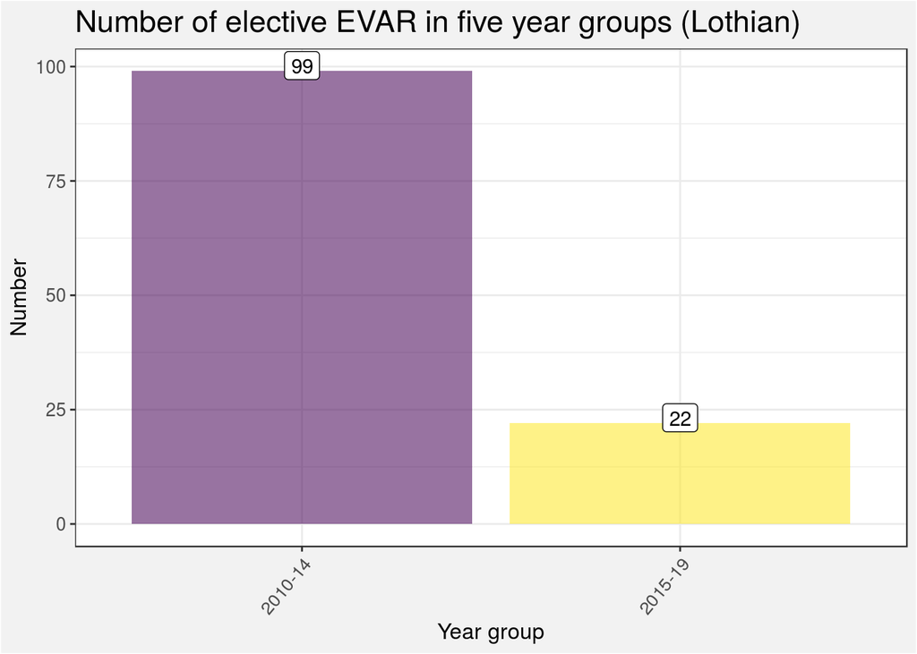

## 1.6 Stent-graft

### 1.6.1 Stent-graft used for elective EVAR

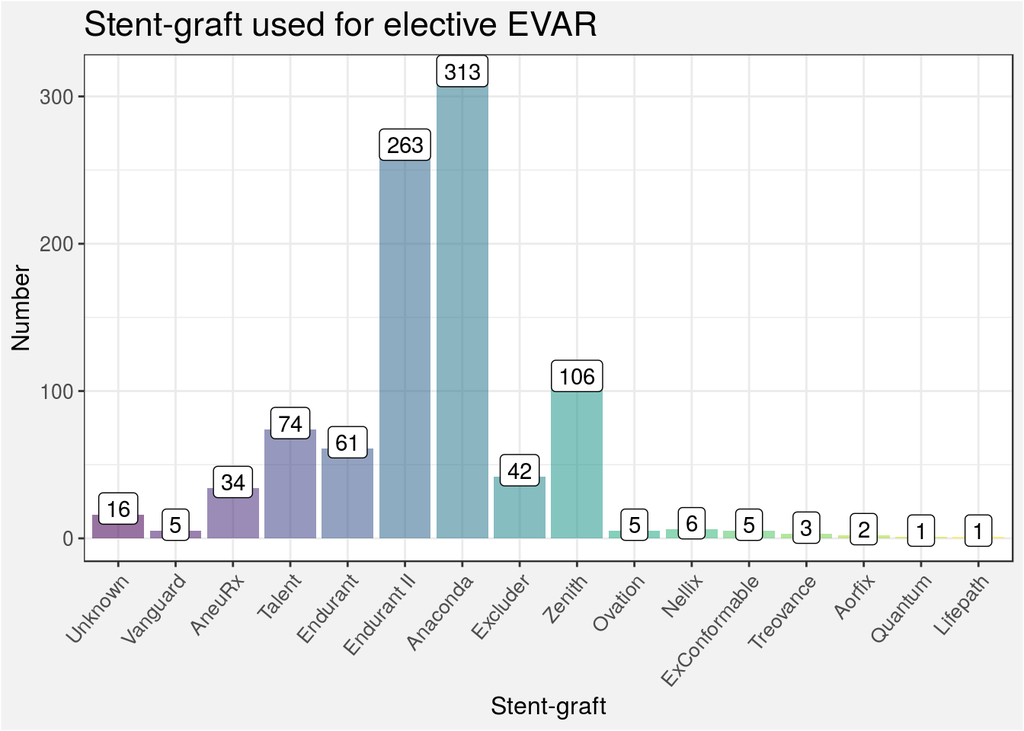

### 1.6.2 Stent-graft used for elective EVAR at each site

- GORE’s Excluder and Excluder Conformable devices have been combined for the following

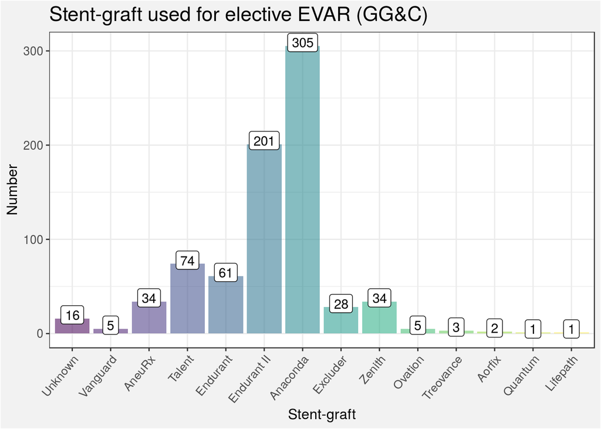

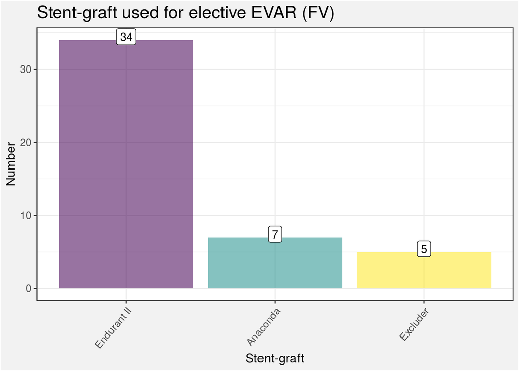

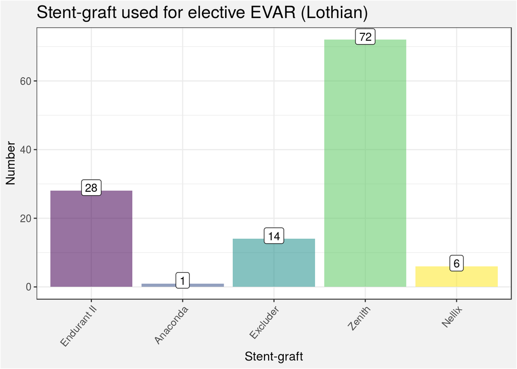

### 1.6.3 Stent-graft used for elective EVAR each year

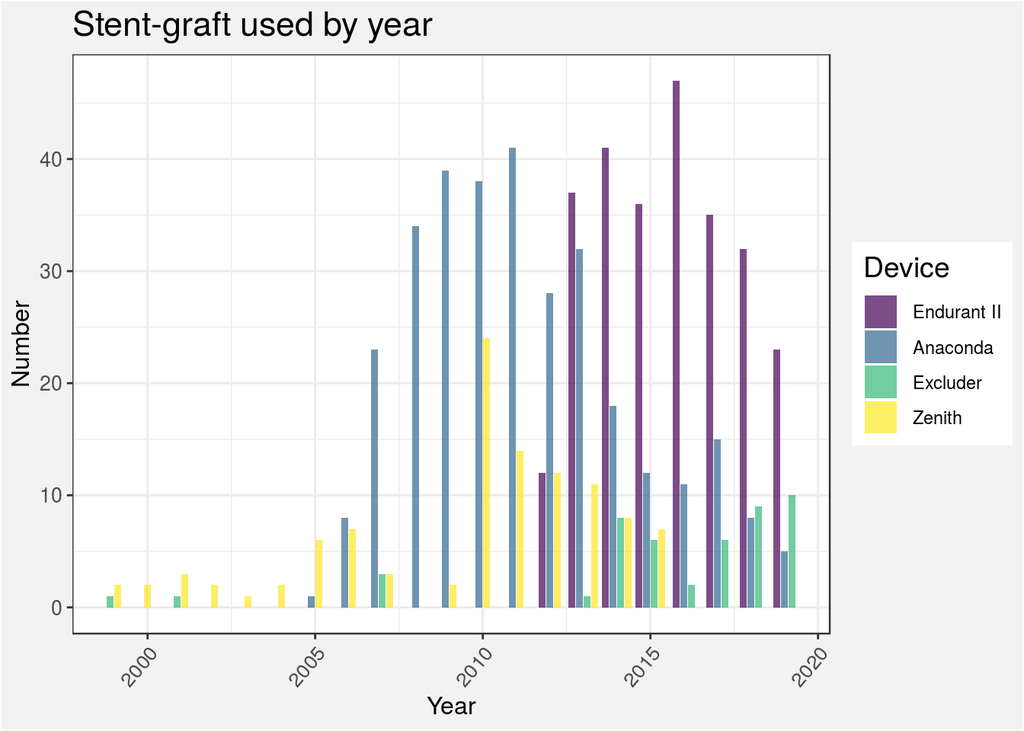

Home